# StatComp Project 1: Simulation and sampling

YUXI ZHENG (s2265133, yuxizheng)

# 1 Confidence interval approximation assessment

We investigate the behavior of an approximate as well as a non-approximate method for confidence interval construction, for the expectation parameter $\lambda$ for observations $y_i\,\,\sim \,\,\mathrm{Pois}\left( \lambda \right)$. We denote the method with approximation as $\mathrm{CI}_1$ and the method with non approximation as $\mathrm{CI}_2$.

## 1.1 Theoretical interval

Let $\mathrm{z}=\,\,\mathrm{z}_{1-\mathrm{\alpha}/2}\,\,=\,\,-\mathrm{z}_{\mathrm{\alpha}/2}$. The confidence interval construction was motivated by the ratio $\frac{\hat{\lambda}-\lambda}{\sqrt{\frac{\lambda}{n}}}$.

For method 1, the parameterization we choose is
$$\theta =\lambda , \hat{\theta}_{ML}=\frac{1}{n}\sum_{i=1}^n{y_i=\overline{y}}.$$
So the ratio for confidence interval construction is approximated by $\frac{\hat{\lambda}-\lambda}{\sqrt{\frac{\widehat{\lambda }}{n}}}$.

For method 2, we use the same parameterization as method 1 but construct the confidence interval by solving the inequality of z-scores and the ratio, which is
$$-z<\frac{\hat{\lambda}-\lambda}{\sqrt{\frac{\lambda}{n}}}<z,$$
for $\alpha <0.5$, $z=z_{1-\alpha /2}>0$.

First we solve the inequality on the left hand side. Let $x=\sqrt{\lambda}$, for the inequality $-z<\frac{\hat{\lambda}-\lambda}{\sqrt{\frac{\lambda}{n}}}$, then
$$-z<\frac{\sqrt{n}\left( \widehat{\lambda }-x^2 \right)}{x}.$$

It is equivalent to
$$\left( x+\frac{a}{2\sqrt{n}} \right) ^2<\hat{\lambda}+\frac{z^2}{4n}.$$

Therefore by solving the inequality, we get
$$-\frac{z}{2\sqrt{n}}-\sqrt{\hat{\lambda}+\frac{z^2}{4n}}<x<-\frac{z}{2\sqrt{n}}+\sqrt{\hat{\lambda}+\frac{z^2}{4n}}.$$

Since $x>0$, by taking the square of $z$, we have
$$\lambda <\hat{\lambda}+\frac{z^2}{2n}+z\sqrt{\frac{\hat{\lambda}}{n}+\frac{z^2}{4n^2}}.$$

Similarly, for the inequality $\frac{\sqrt{n}\left( \widehat{\lambda }-x^2 \right)}{x}<z$, we have
$$\lambda >\hat{\lambda}+\frac{z^2}{2n}-z\sqrt{\frac{\hat{\lambda}}{n}+\frac{z^2}{4n^2}}.$$

## 1.2 Confidence interval coverage

To investigate the empirical coverage of the two methods, we first look at the case $n\,\,=\,\,2, \,\lambda \,\,=\,\,3$ with a nominal coverage of 90%. The estimate of the coverage probability is seen as the proportion of the N simulations that the intervals cover the true $\lambda$ value. In this case, $N\,\,=\,\,10000$ and $\alpha\,\,=\,\,0.1$.

The coverage probability is our scale to measure the performance of our two methods. In the table below, we compute the coverage probability for the two methods, and for the case of $n\,\,=\,\,2, \,\lambda \,\,=\,\,3$, the non-approximation method has a closer coverage of 90%.

| n | Approximation Coverage | Difference to 90% Coverage | Non-Approximation Coverage | Difference to 90% Coverage |
| --- | --- | --- | --- | --- |
| 2 | 0.8279 | 0.0721 | 0.9398 | 0.0398 |
| 10 | 0.8883 | 0.0117 | 0.9173 | 0.0173 |
| 50 | 0.8952 | 0.0048 | 0.9068 | 0.0068 |
| 100 | 0.8977 | 0.0023 | 0.9034 | 0.0034 |
| 150 | 0.9001 | 0.0001 | 0.8984 | 0.0016 |
| 200 | 0.8937 | 0.0063 | 0.9070 | 0.0070 |

As shown in the table above, we would like to discuss how the number of observations $\mathrm{n}$ will affect the coverage probability for the two methods. By running the simulations with $n\,\,=\,\,2, 4, 6, ..., 200$, we compute the coverage for each case. The result is shown in the plot below.

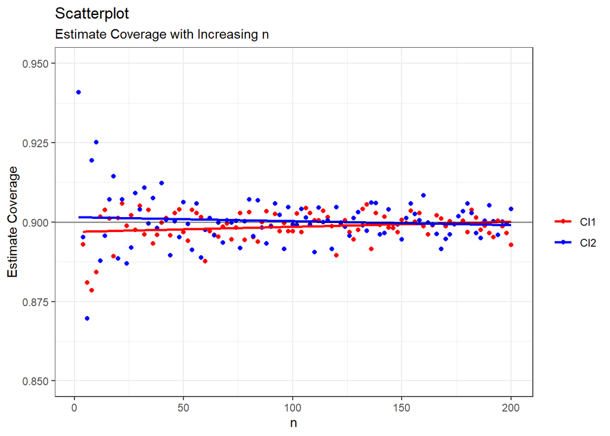

As shown in the plot, in the beginning, when n is relatively small, method 2 is better at predicting the value of $\lambda$ with a non-approximation interval. As n increases, the approximation in method 1 gives a better accuracy when capturing the interval, so that the performance of method 1 improves, even surpasses that of method 2. This improvement of accuracy for MLE estimation shows the approximation method’s high flexibility and the robustness and limitation of the non-approximation method. It is also shown in the theorem that, Given $\widehat{\theta }$, the maximum likelihood estimator for a parameter $\theta$ of distribution, we know that:
$$\sqrt{n}\left( \widehat{\theta }-\theta \right) \,\,\rightarrow N\left( 0,\frac{1}{I\left( \theta \right)} \right),$$
where $I\left( \theta \right)$ is the Fisher information. In this case, we can see how the sample size is playing a crucial role in the method of constructing confidence interval and how we should choose the method accordingly.

# 2 Three Dimension printer materials prediction

Given the CAD weight for observations $x_i$, the corresponding actual weight $y_i$ is modeled as realizations from
$$\mathrm{Normal}\left[ \mathrm{\beta}_1+\mathrm{\beta}_2\mathrm{x}_{\mathrm{i}}, \mathrm{\beta}_3+\mathrm{\beta}_4\mathrm{x}_{\mathrm{i}}^{2} \right]$$
. Let The prior distribution for each $\mathrm{\beta}_{\mathrm{j}}, \mathrm{j} =\,\,1, 2 ,3 , 4$ is shown as follow:
$$\begin{aligned}
\theta _1&\sim \mathrm{Normal}\left( 0,\mathrm{\gamma}_1 \right)
\\
\theta _2&\sim \mathrm{Normal}\left( 1,\mathrm{\gamma}_2 \right)
\\
\mathrm{\theta}_3&\sim \mathrm{LogExp}\left( \mathrm{\gamma}_3 \right)
\\
\,\,\mathrm{\theta}_4&\sim \mathrm{LogExp}\left( \mathrm{\gamma}_4 \right)
\end{aligned}$$
.

## 2.1 Load data

First, we load the data from CAD, where x takes the value of CAD weight and y takes the actual weight value. From the physics assumption, the error in CAD weight is proportional to the weight itself. By plotting the data, we can see this probable tendency.

In the following sections, we will start by constructing a Bayesian method and importance sampling for estimating parameters for our model. Then we will implement them and discuss the results in detail.

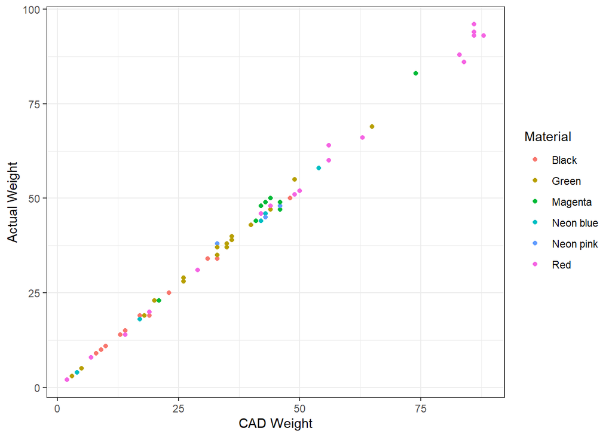

## 2.2 Prior density

Given the parameters $\left( \mathrm{\gamma}_1, \mathrm{\gamma}_2, \mathrm{\gamma}_3, \mathrm{\gamma}_4 \right)$, we want to compute the prior density for a set of $\left( \theta _1, \theta _2, \theta _3, \theta _4 \right)$. We can compute the prior density for $\theta$ respectively with the distributions mentioned above, by using `dnorm` for $\theta_1$, $\theta_2$ and `dlogexp` for $\theta_3$, $\theta_4$. By taking logarithmic value of the density, the logarithmic joint density is
$$\log \left( \mathrm{p}\left( \theta |\lambda \right) \right) \,\,=\,\,\sum_{i=1}^4{\log \left( \mathrm{p}\left( \theta _i|\lambda \right) \right)}.$$

## 2.3 Observation likelihood

When given the observation values of $y_i$ and the ideal values of $x_i$ with the sample size $n$, we could in turn compute the observation likelihood for a set of $\left( \theta _1, \theta _2, \theta _3, \theta _4 \right)$ using `dnorm` The logarithmic observation likelihood for each $\theta_j$ is
$$\log \left( \mathrm{p}\left( y|x,\theta \right) \right) =\sum_{i=1}^n{\log \left( \mathrm{p}\left( y_i|x_i,\theta \right) \right)}.$$

## 2.4 Posterior density

With the prior density and the observation likelihood, we can compute the posterior density. We know that
$$\mathrm{p}\left( \theta |y \right) =\frac{\mathrm{p}\left( y|\theta \right) \mathrm{p}\left( \theta \right)}{\mathrm{p}\left( y \right)}.$$

Since we want to find the MLE for $\theta$, the marginal density for y, $\mathrm{p}\left( \mathrm{y} \right)$ can be ignored in the optimization process so the value returned in `log_posterior_density` omits it. the logarithmic posterior density is
$$\log \left( \mathrm{p}\left( \theta |y \right) \right) \,\,=\,\,\log \left( \mathrm{p}\left( \theta \right) \right) \,\,+\,\,\log \left( \mathrm{p}\left( y|\theta \right) \right) \,\,-\,\,\log \left( \mathrm{p}\left( y \right) \right) .$$

## 2.5 Posterior mode and Gaussian approximation

Given that $\mathrm{\gamma}_{\mathrm{i}}\,\,=\,\,1, \mathrm{i} =1, 2, 3, 4$, with data for $x$ and $y$, we could find the posterior mode for $\theta$ when the posterior density is maximized using `optim`. By obtaining the mode $\mathrm{\theta}_{\mathrm{MLE}}$ and the corresponding inverse of the negated Hessian$-\mathrm{H}^{-1}$, the multivariate Normal approximation is
$$\mathrm{Normal}\left( \mathrm{\theta}_{\mathrm{MLE}}, -\mathrm{H}^{-1} \right).$$

For our case of 3D printer prediction, we compute the mode and the negated Hessian matrix for $\theta$.

```
## The mode is:
```

```
## [1] -0.1008234  1.0800211 -2.9834581 -6.7584316
```

```
## The inverse negated Hessian matrix is:
```

```
##               [,1]           [,2]        [,3]          [,4]
## [1,]  0.0082951754 -0.00034312870  0.03033564 -0.0042956177
## [2,] -0.0003431287  0.00002995519 -0.00149660  0.0002120789
## [3,]  0.0303356429 -0.00149660044  1.06644653 -0.1239715050
## [4,] -0.0042956177  0.00021207885 -0.12397151  0.0454331418
```

## 2.6 Importance sampling function

In `do_importance`, we first generate $N$ observations $\mathrm{\eta}_{\mathrm{i}}, \mathrm{i} =1,...,\mathrm{N}$, from $\mathrm{Normal}\left( \mathrm{\mu}, \mathrm{S} \right)$, where the mean and the covariance matrix are given. Then for each set of sample $\theta_i$, the logarithmic weights is
$$\log \left( w_i \right) \,\,=\,\,\log \left( \mathrm{p}\left( \theta _i \right) \right) \,\,+\,\,\log \left( \mathrm{p}\left( y|\theta _i \right) \right) \,\,-\,\,\log \left( \mathrm{\tilde{p}}\left( \theta _i|y \right) \right).$$

In order to make sure that the sum of the weights is 1, the logarithmic normalized weight is used,
$$\log \left( w_{i\_\mathrm{normalized}} \right) \,\,=\,\,\log \left( w_i \right) \,\,-\,\,\log \left( \sum_j{\exp \left( w_j \right)} \right).$$

## 2.7 Importance sampling amd CDF plots

With the functions defined above, we generate the importance sample with size of 10000, the empirical weighted CDF together with the un-weighted CDF for $\beta_i,i=1,2,3,4$ is shown below. The importance weighted sample is very close to the original one.

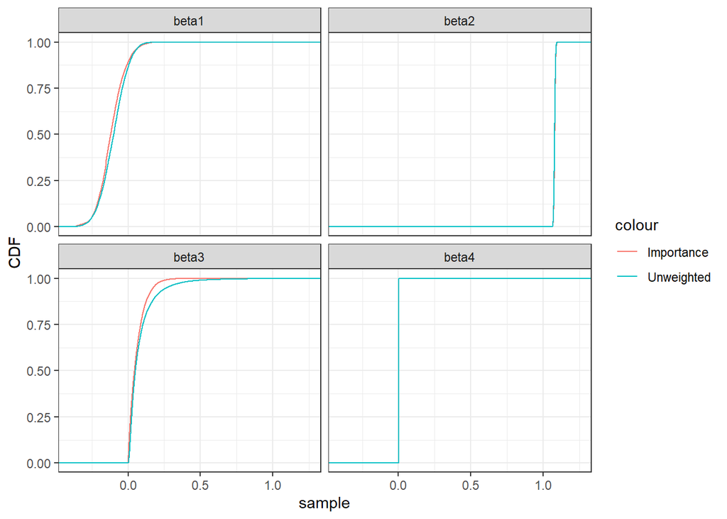

We know that if x is from a Normal distribution, the prior and posterior for the mean parameter are conjugate distributions, specifically, for $\mu \,\,\sim \,\,\mathrm{N}\left( a,b^2 \right)$, the posterior distribution is
$$\mu \,\,\sim \mathrm{N}\left( \frac{\frac{a}{b^2}+\frac{n\overline{x}}{\sigma ^2}}{\frac{n}{\sigma ^2}+\frac{1}{b^2}},\frac{1}{n/\sigma ^2+\frac{1}{b^2}} \right).$$

Therefore we can investigate the distribution of $\beta_1$ samples to find possible improvements. With the information provided above, when plotting CDF of a normal distribution with our weighted and original samples, we can see that it is reasonable that we model $\beta_1$ with a normal distribution. The importance sampling estimation is approximately the same as the given normal distribution. The un-weighted sample is also close to the given normal distribution. Therefore, the Gaussian approximation of the posterior distribution of $\beta_1$ could be a good approximation for our 3D printer model. For $\beta_i, i = 2,3,4$, further information for investigation is needed. Suppose we keep subtracting information of the density using this method. In that case, we could improve our prior distribution so that even with limited data, we could achieve a level of accuracy for $\beta$.

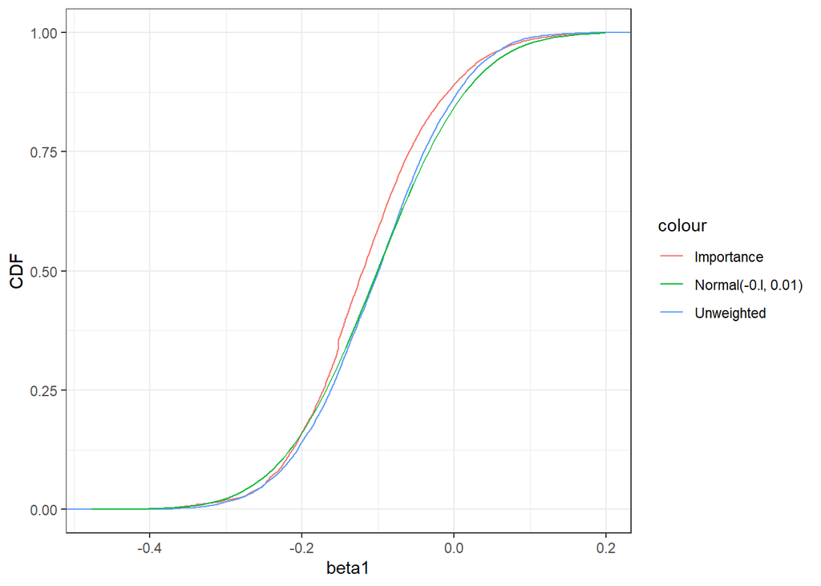

## 2.8 Confidence interval with importance sampling

Now we can predict $\beta$ with a weighted confidence interval. Using the `wquantile`, we construct the confidence interval for $\theta$ with the importance sample, shown in the table below.

|  | Lower | Upper | Width |
| --- | --- | --- | --- |
| Beta 1 | -0.2509095 | 0.0428102 | 0.2937197 |
| Beta 2 | 1.0714550 | 1.0896764 | 0.0182214 |
| Beta 3 | 0.0039901 | 0.1750334 | 0.1710433 |
| Beta 4 | 0.0008583 | 0.0017067 | 0.0008484 |

## 2.9 Prediction interval plots

We now investigate the prediction of our model by first comparing it to a model with linear estimation, then discussing the results from the view both mathematically and in a production application.

We have computed the point estimation for $\beta$ in the “Posterior mode and Gaussian approximation” section. By defining a function to calculate the 90% confidence interval and mean and standard deviation for a given CAD weight, which is `model_prediction`, the prediction interval plot based on point estimates of the parameters is shown below. In the view of the 3D printer application, the model accurately measures the proportion of increasing variance, with most of the points falling into the interval.

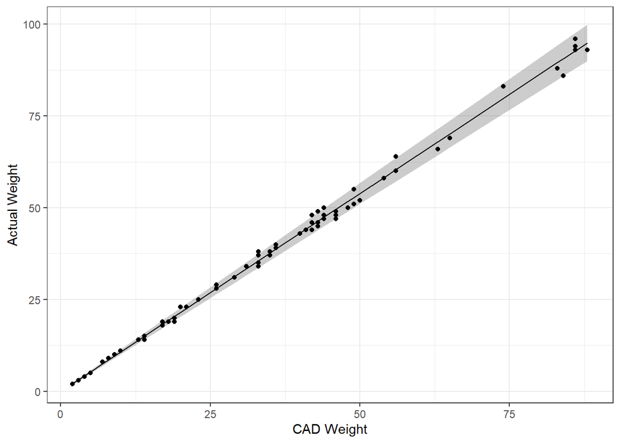

To better analyze it, we compute scores for our model. The squared error, Dawid-Sebastiani, and interval scores with 90% coverage are below.

| model | squared error | Dawid-Sebastiani | Interval scores |
| --- | --- | --- | --- |
| bayes with entire dataset | 1.783582 | 0.9347014 | 4.623655 |

To further investigate the performance of the model, we build our model from scratch using 50% data for training and 50% for validation. It is shown in the table below. We can see that, with the scores above, our model still provides reasonable prediction.

| model | squared error | Dawid-Sebastiani | Interval scores |
| --- | --- | --- | --- |
| bayes with 50% training data | 1.992828 | 1.32325 | 5.593926 |

From the view of the implementation method, by plotting the prediction interval, it is clear that our sampling method is built on an accurate Bayesian model and has the potential of improvement on accuracy with more input data.

From the view of 3D printer application, firstly, in the model, the variance growing with quadratic speed suggests that one way to narrow down the difference between CAD weight and actual weight is to break the relatively heavy part of the printing object into little pieces, making each part lighter. Secondly, we could investigate the factors that influence $\beta_3$ and $\beta_4$, by introducing parameters related to physics into the prior distribution and performing the modeling process.

## 2.10 Importance weights plot with Beta

To look into the improvement for the sampling method, we plot the importance log-weights for each $\beta$ to investigate the relationship between weights and sampled value. By normalizing the importance weights by their average and scaling them logarithmically, we know that the value above 1 has corresponding sample values that should occur more often in the true target distribution than in raw samples and vice versa.

For $\beta_1$, there is a mild suggestion that the value should have landed more on the negative side. For $\beta_3$, it is shown that value should have concentrated in the area around 0 to 0.5; instead, in the sample, it spreads to some larger values. For $\beta_4$, less value should have concentrated in the area that is approximately smaller than 0.0015. For $\beta_i, i=1,2,4$, we can see that the weights form a relatively balanced plot, with most weights close to 1. This also indicates that the sample is in accord with the true target distribution.

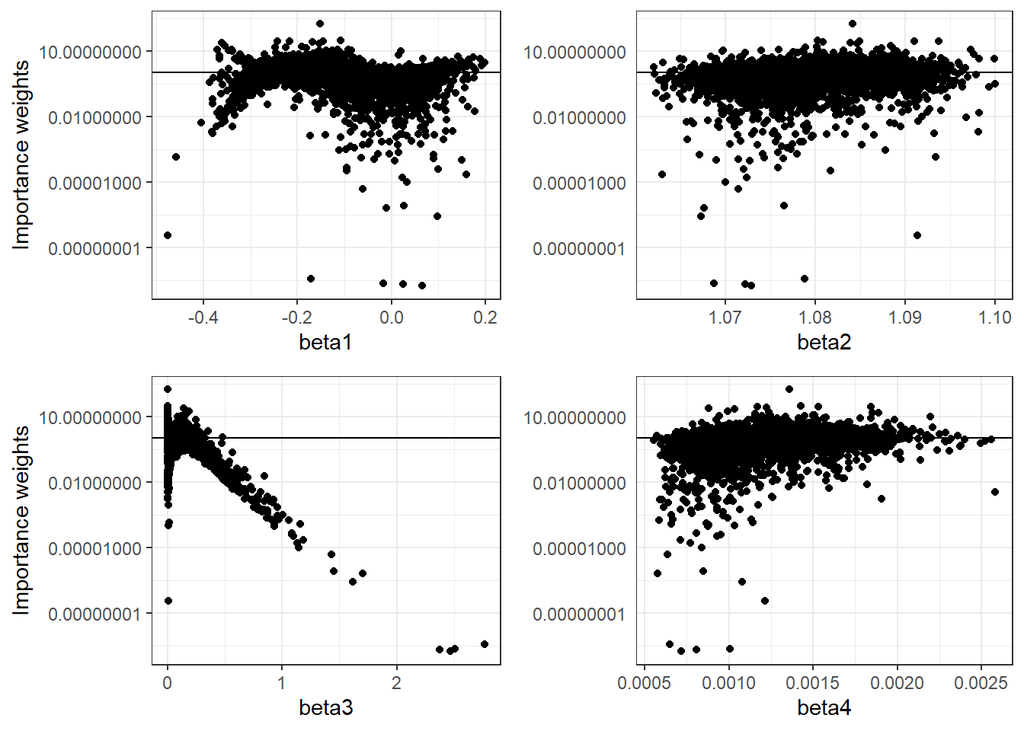

## 2.11 Effective sample size

The importance weights plots indicate that the sampling method may have the potential of improvement. By computing the effective sample size $\frac{\left( \sum_k{w_k} \right) ^2}{\sum_k{w_k^2}}$, we know that the current sample size is ideal.

```
## The effective sample size is:
```

```
## [1] 9871.161
```

### 2.11.1 Summary

We implement our model with importance sampling, discuss the performance numerically and practically. The CDF plots imply that there is still information unveiled between CAD weights and $\beta$; more patterns could be found in the posterior distribution. From the prediction interval, we investigate how actual weights waver by the influence of CAD weights. Last, we look into the relationship between weights and value of $\beta$ in the sampling method and discuss possible improvements.

# 3 Code appendix

```r
#' Yuxi Zheng, s2265133, yuxizheng
#' Add your own function definitions at the top of this file.

#' Confidence Interval with Approximation
#'
#' Compute the confidence interval with method of approximation, given i.i.d. observations
#'
#' @param y vector of observations
#' @param alpha 1-alpha is the intended coverage probability
#'
#' @return CI the confidence interval with 90% coverage
CI_approx <- function(y, alpha = 0.05) {

  n <- length(y)
  lambda_hat <- mean(y)

  # interval for given normal distribution
  theta_interval <-
    lambda_hat - sqrt(lambda_hat / n) * qnorm(c(1 - alpha / 2, alpha / 2))

  # make sure the interval is positive
  CI <- pmax(theta_interval, 0)

  CI
}

#' Confidence Interval with Non Approximation
#'
#'  Compute the confidence interval with method of non-approximation, given i.i.d. observations
#'
#' @param y vector of observations
#' @param alpha 1-alpha is the intended coverage probability
#'
#' @return CI the confidence interval with 90% coverage
CI_non_approx <- function(y, alpha = 0.05) {

  n <- length(y)
  lambda_hat <- mean(y)
  a <- qnorm(alpha/2)
  b <- qnorm(1-alpha/2)

  # compute lower and upper
  lower <- b*b/(2*n) - b*sqrt(lambda_hat/n + b^2/(4*n*n)) + lambda_hat
  upper <- a*a/(2*n) - a*sqrt(lambda_hat/n + a^2/(4*n*n)) + lambda_hat
  theta_interval <- c(lower, upper)

  CI <- pmax(theta_interval, 0)

  CI
}

#' Log prior density
#'
#' Compute the logarithm of the joint prior density
#'
#' @param theta vector of theta parameter
#' @param params vector of gamma parameter
#'
#' @return log_pd computed log prior density
log_prior_density <- function(theta, params) {
  # compute joint log density
  log_pd <- dnorm(theta[1], mean = 0, sd = sqrt(params[1]), log = TRUE) +
  dnorm(theta[2], mean = 1, sd = sqrt(params[2]), log = TRUE) +
  dlogexp(theta[3], rate = params[3], log = TRUE) +
  dlogexp(theta[4], rate = params[4], log = TRUE)

  log_pd
}

#' Log Observation likelihood
#'
#' Compute the logarithm of the likelihood
#'
#' @param theta vector of theta parameter
#' @param x vector of x
#' @param y vector of y
#'
#' @return log_likelihood computed log likelihood
log_like <- function(theta, x, y) {
  # compute log density for samples
  log_f <- dnorm(y, mean = theta[1] + theta[2] * x, sd = sqrt(exp(theta[3]) + exp(theta[4]) * x^2), log = TRUE)
  log_likelihood <- sum(log_f)

  log_likelihood
}

#' Posterior density
#'
#' Compute the log posterior density, ignoring un-evaluated part
#'
#' @param theta vector of theta parameter
#' @param x vector of x
#' @param y vector of y
#' @param params vector of gamma parameter
#'
#' @return log_post log_posterior density
log_posterior_density <- function(theta, x, y, params) {

  log_post <- log_prior_density(theta, params) + log_like(theta, x, y)

  log_post
}

#' Importance Sampling
#'
#' Compute 90% Bayesian credible interval for each 尾j using importance sampling
#'
#' @param N The number of samples to generate
#' @param mu The mean vector for the importance distribution
#' @param S The covariance matrix
#'
#' @return df data frame of samples and log-weights
do_importance <- function(N, mu, S, x, y, params, ...) {

  sample <- rmvnorm(N, mean = mu, sigma = S)
  log_weights <- vector(length = N)

  # for each of the simulated theta, calculate log weights
  for (i in 1:N) {
    log_weights[i] <- log_posterior_density(theta = sample[i,], x = x, y = y, params = params) -
      dmvnorm(sample[i,], mean = mu, sigma = S, log = TRUE)
  }

  # normalization
  log_weights <- log_weights - log_sum_exp(log_weights)

  # compute weights
  sample[, 3] <- exp(sample[, 3])
  sample[, 4] <- exp(sample[, 4])

  df <- data.frame(cbind(sample, log_weights))
  colnames(df) <- c("beta1", "beta2", "beta3", "beta4", "log_weights")

  df
}

#' Construct credible intervals using importance sampling
#'
#' Compute credible intervals as dataframe
#'
#' @param x vector of samples
#' @param weights vector of weights
#' @param prob intended coverage probability
#'
#' @param df data frame of confidence interval for samples
make_CI <- function(x, weights, prob) {

  alpha <- 1-prob
  theta_interval <- wquantile(x, probs = c(alpha/2, 1-alpha/2), weights = weights)

  df <- data.frame(t(theta_interval))
  colnames(df) <- c("Lower", "Upper")

  df
}

#' Construct confidence intervals for input data of
#'
#' Compute mean, sd, lwr, upr for the normal distribution model as list
#'
#' @param x vector of CAD weights
#' @param theta vector of theta parameters
#' @param prob confidence level
#'
#' @return model_pred data frame of prediction information
model_prediction <- function(x, theta, prob){

  n <- length(x)
  alpha <- (1-prob) / 2
  mean <- vector()
  sd <- vector()
  lwr <- vector()
  upr <- vector()

  # compute upper and lower, mean and sd for the point
  for(i in 1:n){
    mean <- append(mean, theta[1] + theta[2] * x[i])
    sd <- append(sd, sqrt(exp(theta[3]) + exp(theta[4]) * x[i]^2))
    lwr <- append(lwr, mean[i] + qnorm(alpha) * sd[i])
    upr <- append(upr, mean[i] - qnorm(alpha) * sd[i])
  }
  model_pred <- list(mean, sd, lwr, upr)
  names(model_pred) <- c("mean", "sd", "lwr", "upr")

  model_pred
}

#' Log-Exponential density
#'
#' Compute the density or log-density for a Log-Exponential (LogExp)
#' distribution
#'
#' @param x vector of quantiles
#' @param rate vector of rates
#' @param log logical; if TRUE, the log-density is returned

dlogexp <- function(x, rate = 1, log = FALSE) {
  result <- log(rate) + x - rate * exp(x)
  if (!log) {
    exp(result)
  }
  result
}

#' Log-Sum-Exp
#'
#' Convenience function for computing log(sum(exp(x))) in a
#' numerically stable manner
#'
#' @param x numerical vector

log_sum_exp <- function(x) {
  max_x <- max(x, na.rm = TRUE)
  max_x + log(sum(exp(x - max_x)))
}

#' Interval coverage estimation
#'
#' @param CI_method a function object taking arguments x and alpha,
#'   returning a 2-element vector.
#' @param N The number of simulation replications to use for the coverage estimate
#' @param alpha 1-alpha is the intended coverage probability
#' @param n The sample size
#' @param lambda The true lambda values for the Poisson(lambda) model
#'
#' @return A scalar between 0 and 1, estimating the coverage probability
#' for the `CI_method` intervals for the given parameters.

estimate_coverage <- function(CI_method,
                              N = 10000,
                              alpha = 0.1,
                              n = 2,
                              lambda = 3) {
  cover <- 0
  for (loop in seq_len(N)) {
    y <- rpois(n, lambda)
    ci <- CI_method(y, alpha)
    cover <- cover + ((ci[1] <= lambda) && (lambda <= ci[2]))
  }
  cover / N
}
```